# Cell expression

Panteleev Dmitrii

# Download data

We don’t need to eliminate the whole samples(columns) because none of them have all empty observations(or significant part of them contains N/A).

## EDA

Remove genes with half and more missing values

```r
genes_with_NA <- names(which(rowSums(is.na(cells)) > ncol(cells)/2))
cells_without_NA <- cells[!rownames(cells) %in% genes_with_NA,]
```

The result: We filtered 1311 genes.

Imputation with a KNN method:

```r
cells_without_NA <- as.matrix(cells_without_NA)
cells_without_NA_trans <- t(cells_without_NA)
knn_cells <- impute.knn(cells_without_NA_trans, k = 5)
knn_cells <- knn_cells$data
knn_cells <- as.data.frame(knn_cells)

knn_cells <- t(as.matrix(knn_cells))


cells_experiment <- as.factor(c("1", "1", "1", "1","1", "1", "1", "1", "1", "1", "1", "1", "1", "1", "2", "2", "2", "2", "2", "2", "2", "2", "2", "2", "2", "2", "2" , "2", "2", "2", "2", "2", "2"))
```

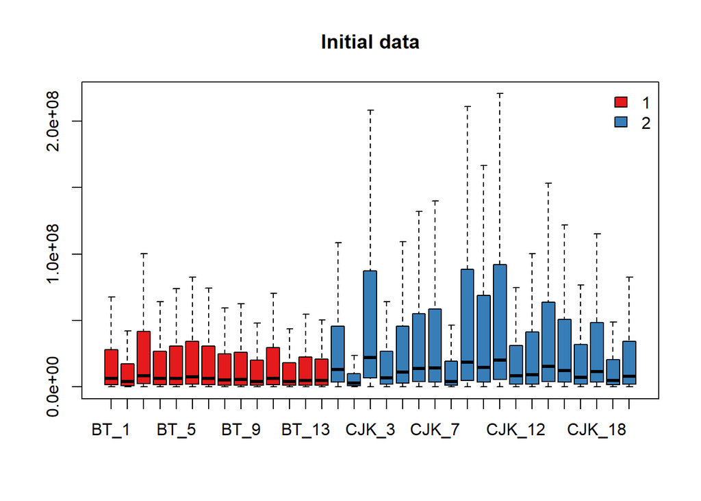

```r
pal <- brewer.pal(n = 9, name = "Set1")
cols <- pal[cells_experiment]
boxplot(knn_cells, outline = FALSE, main = "Initial data", col = cols)
legend("topright", levels(cells_experiment), fill = pal, bty = "n", xpd = T)
```

Data normalization:

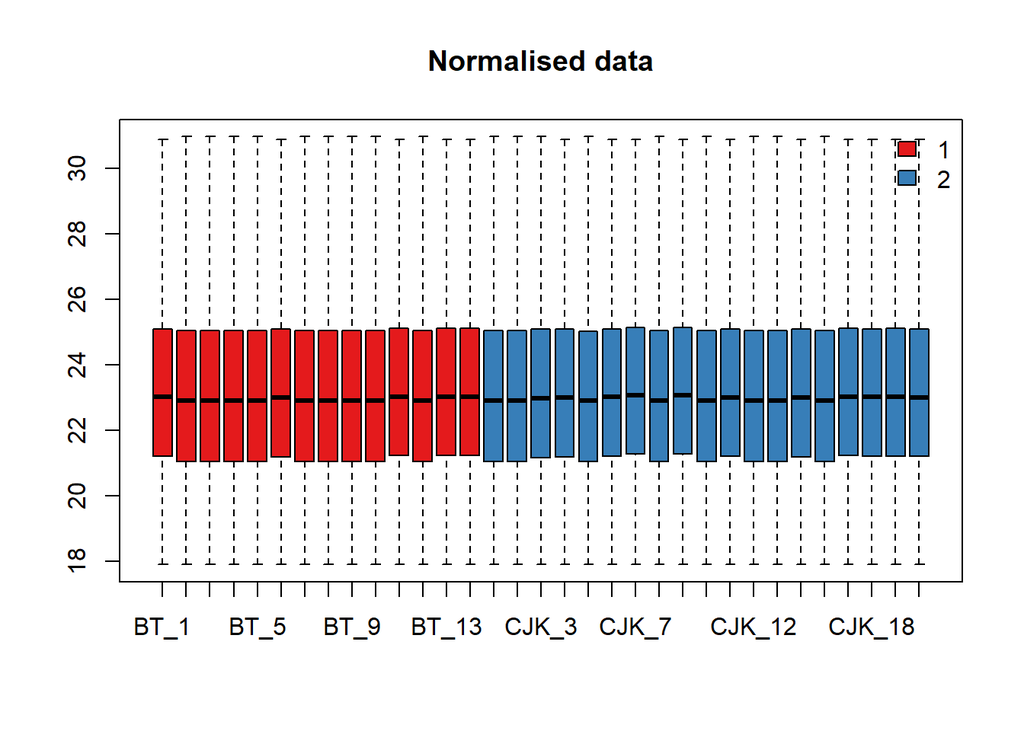

```r
cells_log <- log2(knn_cells)
cells_norm <- normalizeQuantiles(as.matrix(cells_log))
boxplot(cells_norm, outline = FALSE, main = "Normalised data", col = cols)
legend("topright", levels(cells_experiment), fill = pal, bty = "n", xpd = T)
```

```r
colSums(is.infinite(cells_norm))
```

```
##   BT_1   BT_2   BT_3   BT_4   BT_5   BT_6   BT_7   BT_8   BT_9  BT_10  BT_11
##     43    105    105    105    103     49    105    105    105    105     35
##  BT_12  BT_13  BT_14  CJK_1  CJK_2  CJK_3  CJK_4  CJK_5  CJK_6  CJK_7  CJK_8
##    105     31     31    105    105     61     47    105     43     13    105
##  CJK_9 CJK_10 CJK_11 CJK_12 CJK_13 CJK_14 CJK_16 CJK_17 CJK_18 CJK_19 CJK_20
##     13    105     45    105    105     51    103     33     43     39     45
```

We can see that Median and Mean of box plots have became more similar than before a normalization step, but also we can notice that we have a slight fluctuation between samples at this plot. This may be due to the null values of knn_cells and -inf-values of cells_nnm as a result of logarithm. That is why I decided to add +1 to eliminate -inf:

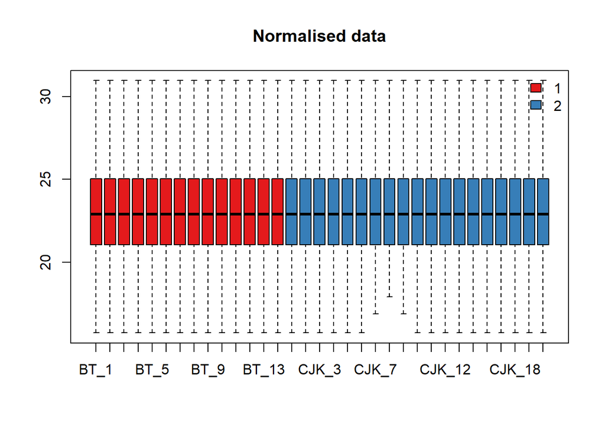

```r
cells_log <- log2(knn_cells+1)
cells_norm <- normalizeQuantiles(as.matrix(cells_log))
boxplot(cells_norm, outline = FALSE, main = "Normalised data", col = cols)
legend("topright", levels(cells_experiment), fill = pal, bty = "n", xpd = T)
```

This result is more better then previous one, because our cells_norm hasn’t -inf data.

```r
colSums(is.infinite(cells_norm))
```

```
##   BT_1   BT_2   BT_3   BT_4   BT_5   BT_6   BT_7   BT_8   BT_9  BT_10  BT_11
##      0      0      0      0      0      0      0      0      0      0      0
##  BT_12  BT_13  BT_14  CJK_1  CJK_2  CJK_3  CJK_4  CJK_5  CJK_6  CJK_7  CJK_8
##      0      0      0      0      0      0      0      0      0      0      0
##  CJK_9 CJK_10 CJK_11 CJK_12 CJK_13 CJK_14 CJK_16 CJK_17 CJK_18 CJK_19 CJK_20
##      0      0      0      0      0      0      0      0      0      0      0
```

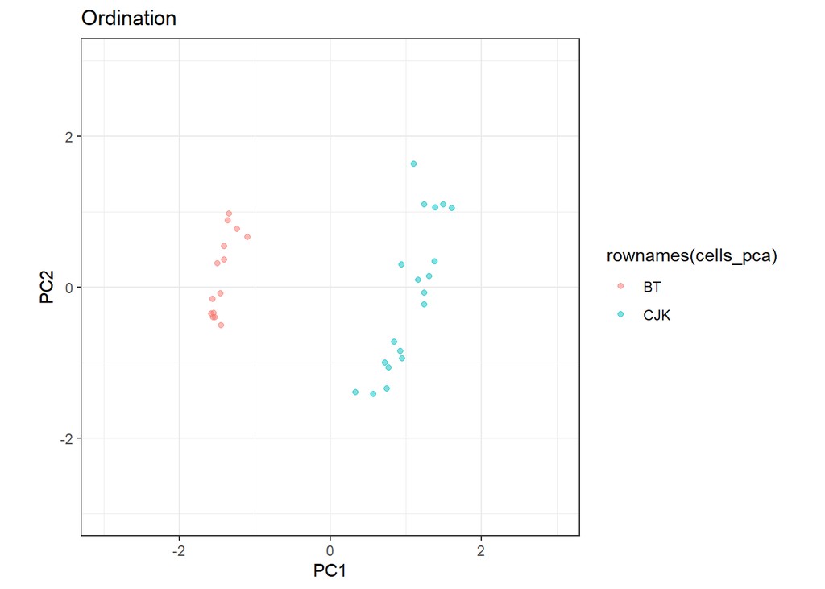

```r
cells_pca <- t(cells_norm)
terapod_pca <- rda(cells_pca, scale = TRUE)

rownames(cells_pca) <- c("BT", "BT","BT", "BT","BT", "BT","BT", "BT","BT", "BT","BT", "BT","BT", "BT", "CJK", "CJK", "CJK", "CJK", "CJK", "CJK","CJK", "CJK", "CJK", "CJK","CJK", "CJK", "CJK", "CJK", "CJK", "CJK","CJK", "CJK", "CJK")


df_scores <- data.frame(cells_pca,
                        scores(terapod_pca, display = "sites", choices = c(1, 2, 3), scaling = "sites"))

p_scores <- ggplot(df_scores, aes(x = PC1, y = PC2)) +
  geom_point(aes(color = rownames(cells_pca)), alpha = 0.5) +
  coord_equal(xlim = c(-3, 3), ylim = c(-3, 3)) + ggtitle(label = "Ordination") + theme_bw()
p_scores
```

MA-plot for a comparison of groups

```r
maplot <- function(X1, X2, pch = 21, main = "MA-plot", xlab = "Average log-expression", ylab = "Expression log-ratio", lpars = list(col = "blue", lwd = 2), ...){

  X <- (rowMeans(X2) + rowMeans(X1)) / 2
  Y <- rowMeans(X2) - rowMeans(X1)

  scatter.smooth(x = X, y = Y, main = main, pch = pch, xlab = xlab, ylab = ylab, lpars = lpars, ...)
  abline(h = c(-1, 0, 1), lty = c(2, 1, 2))
}
```

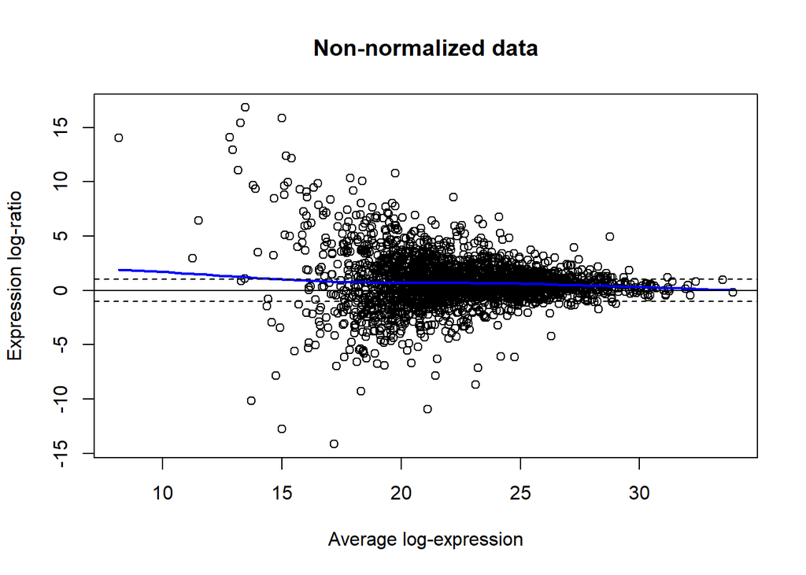

```r
maplot(cells_log[,1:14], cells_log[,15:33],  main = "Non-normalized data")
```

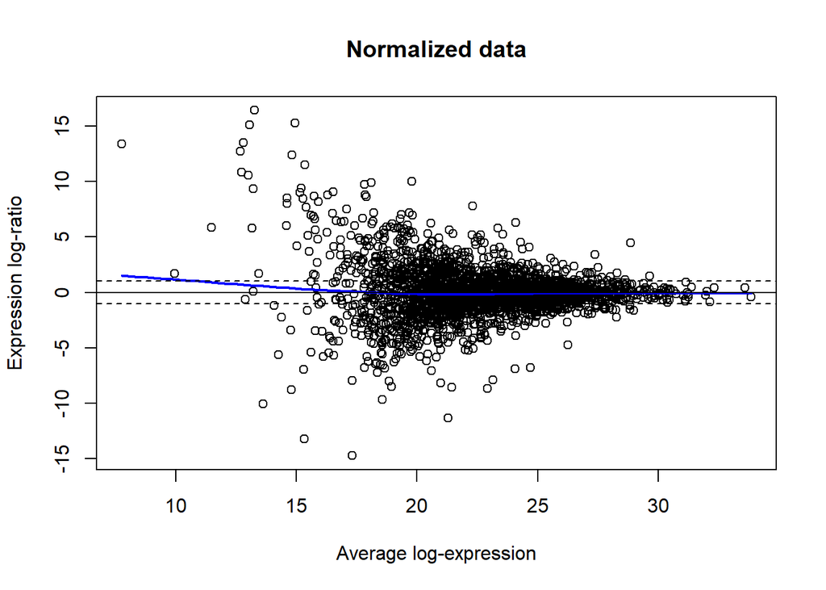

```r
maplot(cells_norm[,1:14], cells_norm[,15:33],  main = "Normalized data")
```

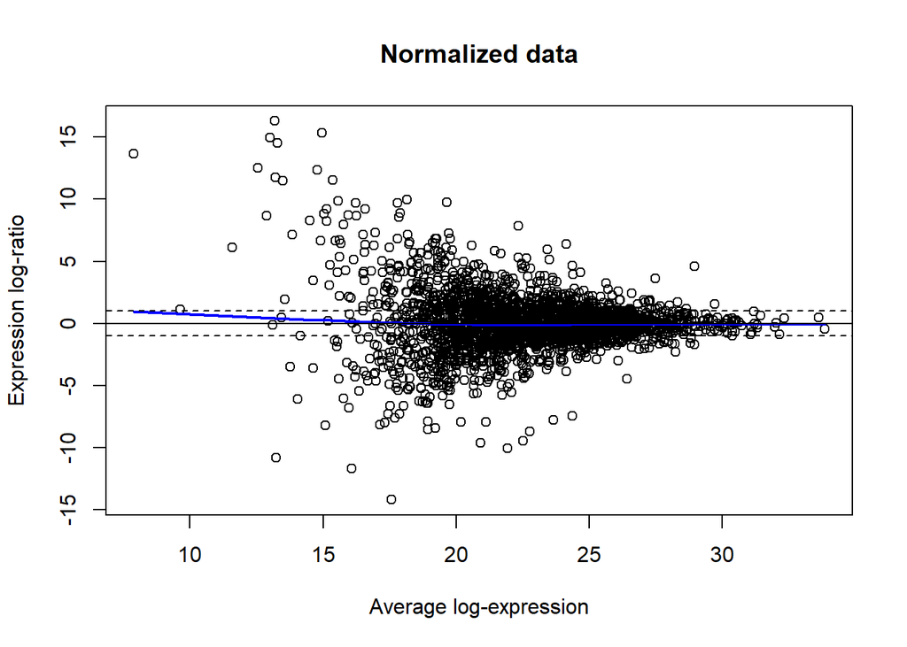

```r
maplot(cells_norm[,1:14], cells_norm[,c(15:20,24:33)],  main = "Normalized data")
```

```r
#cells_norm[,21:23]
```

I don’t see the significant difference between plot, Normalised graph is less curved. The normalization step didn’t impact on it strongly. We can excude problematic columns and a line can be less curved.

### Dif expression

```r
expr_data <- as.matrix(cells_norm)


pheno_data <- data.frame(cells_experiment)
rownames(pheno_data) <- colnames(cells_norm)
pheno_metadata <- data.frame(
  labelDescription = c("Experimental condition"),
  row.names=c("Condition"))
pheno_data <- new("AnnotatedDataFrame",
                 data = pheno_data,
                 varMetadata = pheno_metadata)

feature_data <- data.frame(Prot = rownames(expr_data))
rownames(feature_data) <- rownames(expr_data)
feature_metadata <- data.frame(
  labelDescription = c("Protein name"),
  row.names = c("Protein"))
f_data <- new("AnnotatedDataFrame",
              data = feature_data,
              varMetadata = feature_metadata)


exp_set <-
  ExpressionSet(assayData = expr_data,
                phenoData = pheno_data,
                featureData = f_data)
```

We got ExpressionSet with all our data.

```r
X <- model.matrix(~ cells_experiment, pData(exp_set))
fit <- lmFit(exp_set, design = X, method = "robust", maxit = 1000)

efit <- eBayes(fit)
```

We performed Empirical Bayes statistics and now we have differentially expressed proteins

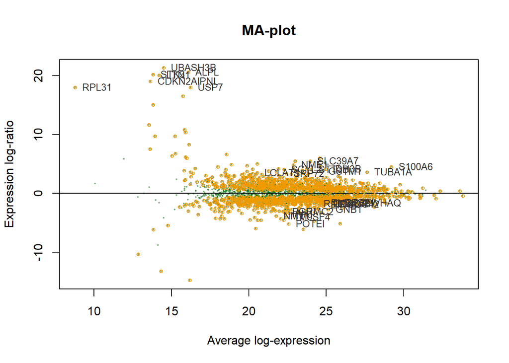

```r
MA_limma <- function(efit, coef, n = 10, signif = TRUE, fdr = 0.05, lfc = 0, text = TRUE, cex.text = 0.8, col.text = "grey20", main = "MA-plot", xlab = "Average log-expression", ylab = "Expression log-ratio", pch = 19, pch.signif = 21, col = "darkgreen", alpha = 0.3, cex = 0.3, ...){

  R <- efit$coefficients[, coef]
  I <- efit$Amean

  col_btransp <- adjustcolor(col, alpha.f = alpha)

  plot(I, R, cex = cex, main = main, pch = pch, xlab = xlab, ylab = ylab, col = col_btransp, ...)
  abline(h = 0)

  if(signif){
    sign <- p.adjust(efit$p.value[, coef], method = "BH") <= fdr
    large <- abs(efit$coefficients[, coef]) >= lfc
    points(I[sign & large], R[sign & large], cex = cex*2, col = "orange2", pch = pch.signif)
  }

  if(text){
    ord <- order(efit$lods[, coef], decreasing = TRUE)
    top_n <- ord[1:n]
    text(I[top_n], R[top_n], labels = efit$genes[top_n, ], pos = 4, cex = cex.text, col = col.text)
  }
}


MA_limma(efit, coef = 2, n = 30)
```

We can see at this MA plot dif exp proteins like orange points and the name of first 30 protein.

```r
# We can get top 100 proteins for the further study

my_list <- topTable(efit, coef = 2, n = 100)

dif_exp_set <- exp_set[fData(exp_set)$Prot %in% my_list$Prot, ]
```

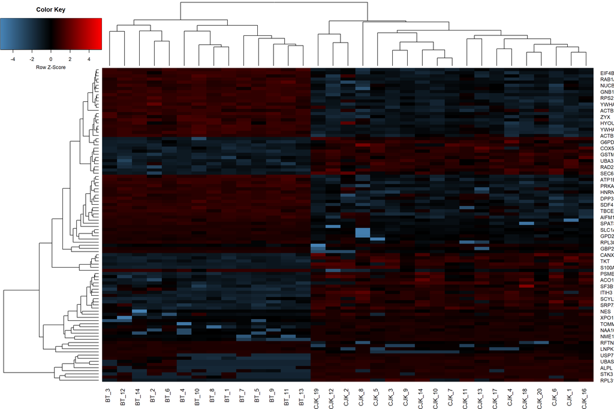

```r
dat <- as.matrix(exprs(dif_exp_set))

pal_blue_red <- colorpanel(75, low = "steelblue", mid = "black", high = "red")
heatmap.2(dat, col = pal_blue_red, scale = "row", key = TRUE, symkey = FALSE, density.info = "none", trace = "none", cexRow = 0.9, cexCol = 1, margins = c(4, 3), keysize = 0.8, key.par = list(mar = c(3, 0.1, 3, 0.1)))
```

We can see different patterns between BT and CJK samples. It’s a good result. We can notice an explicit group of that up or down regulated in BT samples.

```r
topTable(efit, coef = 2)
```

```
##                  Prot     logFC   AveExpr         t      P.Value    adj.P.Val
## STK3             STK3 20.184287 13.818643  86.15582 1.572367e-40 3.567701e-37
## UBASH3B       UBASH3B 21.304975 14.492962  73.33800 3.167846e-38 3.593922e-35
## LTN1             LTN1 20.044093 14.208426  69.10768 2.236744e-37 1.691724e-34
## RPL31           RPL31 18.005300  8.767042  62.50010 6.079626e-36 3.448668e-33
## CDKN2AIPNL CDKN2AIPNL 19.002394 13.644314  37.51505 1.045517e-28 4.744557e-26
## TM9SF4         TM9SF4 -4.037415 22.404294 -26.88379 4.570027e-24 1.728232e-21
## NME1             NME1  4.856379 22.897712  26.71538 5.577016e-24 1.807750e-21
## GSTM1           GSTM1  3.764886 24.666582  24.91492 5.051028e-23 1.432598e-20
## ALPL             ALPL 20.574177 16.090517  21.41857 5.671143e-21 1.429758e-18
## NMT1             NMT1 -3.814701 21.758641 -21.14529 8.434987e-21 1.913898e-18
##                   B
## STK3       74.81069
## UBASH3B    71.47699
## LTN1       70.22515
## RPL31      67.66626
## CDKN2AIPNL 54.44613
## TM9SF4     44.65367
## NME1       44.52567
## GSTM1      42.41828
## ALPL       37.78289
## NMT1       37.42582
```

```r
numGenes <- nrow(exprs(exp_set))
full_list <- topTable(efit, number = numGenes)
```

```
## Removing intercept from test coefficients
```

```r
full_list <- full_list[full_list$adj.P.Val <= 0.05,]
write.csv(full_list, 'C:/Users/matt/Desktop/proteomicsHW/DE_full.csv')
```

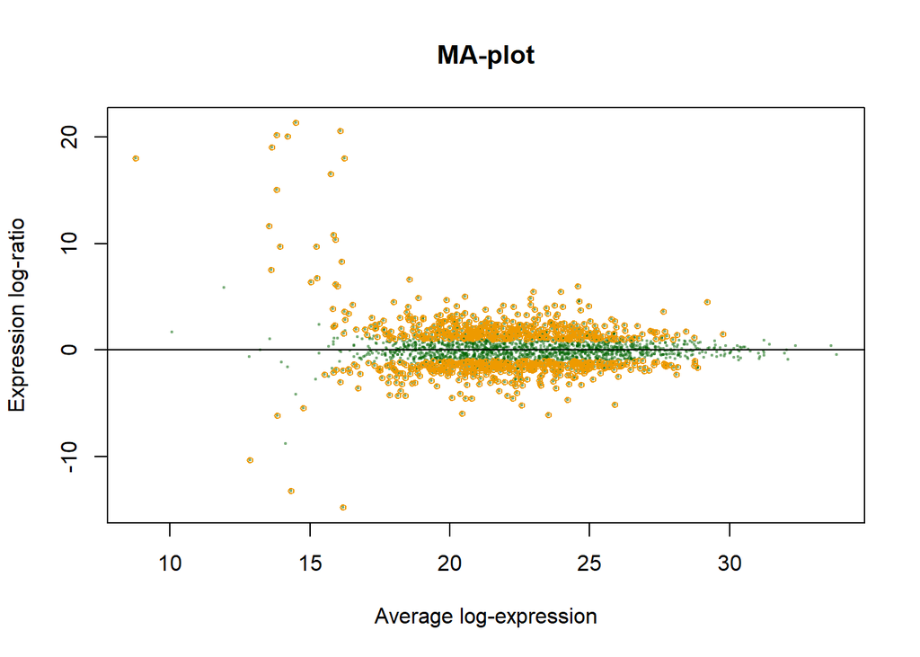

```r
MA_limma(efit, coef = 2, n = 80, text = F, lfc = 1)
```

```r
my_list <- full_list

dif_exp_set <- exp_set[fData(exp_set)$Prot %in% my_list$Prot, ]
```

# Volcano plot

```r
volcano_list <- full_list

volcano1 <- ggplot(data = volcano_list, aes(x = logFC, y = -log10(adj.P.Val))) + geom_point()

volcano2 <- volcano1 + geom_vline(xintercept=c(-1, 1), col="red") +
  geom_hline(yintercept=-log10(0.05), col="red")

volcano_list$diffexpressed <- "NO"
```

```r
volcano_list$diffexpressed[volcano_list$logFC > 1 & volcano_list$adj.P.Val < 0.05] <- "UP"
```

```r
volcano_list$diffexpressed[volcano_list$logFC < -1 & volcano_list$adj.P.Val< 0.05] <- "DOWN"

volcanodif1 <- ggplot(data = volcano_list, aes(x = logFC, y = -log10(adj.P.Val), col = diffexpressed)) + geom_point() + theme_minimal()
```

Add lines as before…

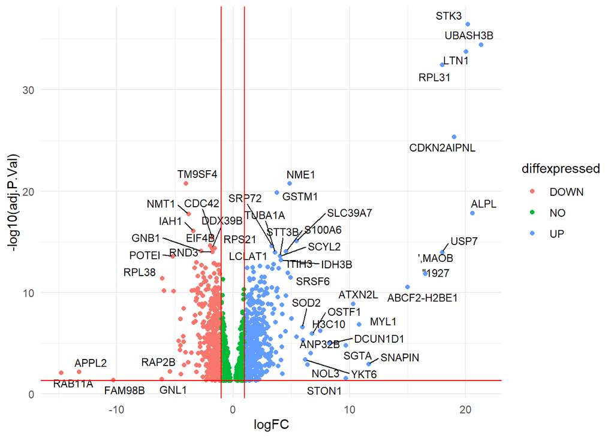

```r
volcanodif2 <- volcanodif1 + geom_vline(xintercept=c(-1, 1), col="red") +
  geom_hline(yintercept=-log10(0.05), col="red")

volcano_list$Prot <- as.character(volcano_list$Prot)
volcano_list$delabel <- NA
volcano_list$delabel[volcano_list$diffexpressed != "NO"] <- volcano_list$Prot[volcano_list$diffexpressed != "NO"]
#volcano_list[volcano_list$adj.P.Val<=0.6,]$delabel <- volcano_list[volcano_list$adj.P.Val<=0.6,]$Prot

plot_proteins <- ggplot(data=volcano_list, aes(x=logFC, y=-log10(adj.P.Val), col=diffexpressed, label=delabel)) +
  geom_point() +
  theme_minimal() +
  geom_text_repel(size=3, colour = 'black', max.overlaps = 30)

plot_final <- plot_proteins + geom_vline(xintercept=c(-1, 1), col="red") + geom_hline(yintercept=-log10(0.05), col="red")
plot_final
```

Here we can see blue, red and greem points, according to up, dowm and non-regulated proteins.

# GO enrichment analysis

In order to group significantly differentially expressed proteins we have used GO enrichment analysis.

```r
# keep only the significant proteins results
sig <- subset(full_list, adj.P.Val < 0.05)
# get the significant up-regulated proteins
up <- subset(sig, logFC > 0)
# get the significant down-regulated proteins
down <- subset(sig, logFC < 0)
```

```r
# needed to convert to enrichResult object
up_names <- gconvert(row.names(up))
down_names <- gconvert(row.names(down))
```

## Up-regulated proteins

```r
# enrichment analysis using proteins names
multi_gp_up_reg <- gost(list("up-regulated" = up_names$name), multi_query = FALSE, evcodes =TRUE)
# modify the g:Profiler data frame
gp_mod_up = multi_gp_up_reg$result[, c("query", "source", "term_id","term_name", "p_value", "query_size", "intersection_size", "term_size", "effective_domain_size", "intersection")]
gp_mod_up <- gp_mod_up[order(gp_mod_up$p_value), ]
gp_mod_up_BP <- gp_mod_up[gp_mod_up$source == "GO:BP", ]
gp_mod_up_BP$GeneRatio <- paste0(gp_mod_up_BP$intersection_size,  "/", gp_mod_up_BP$query_size)
gp_mod_up_BP$BgRatio <- paste0(gp_mod_up_BP$term_size, "/", gp_mod_up_BP$effective_domain_size)
names(gp_mod_up_BP) <- c("Cluster", "Category", "ID", "Description", "p.adjust", "query_size", "Count", "term_size", "effective_domain_size", "geneID", "GeneRatio", "BgRatio")
gp_mod_up_BP$geneID <- gsub(",", "/", gp_mod_up_BP$geneID)
row.names(gp_mod_up_BP) <- gp_mod_up_BP$ID
gp_mod_enrich_up_BP <- new("enrichResult", result = gp_mod_up_BP)
```

Draw enrichment plot:

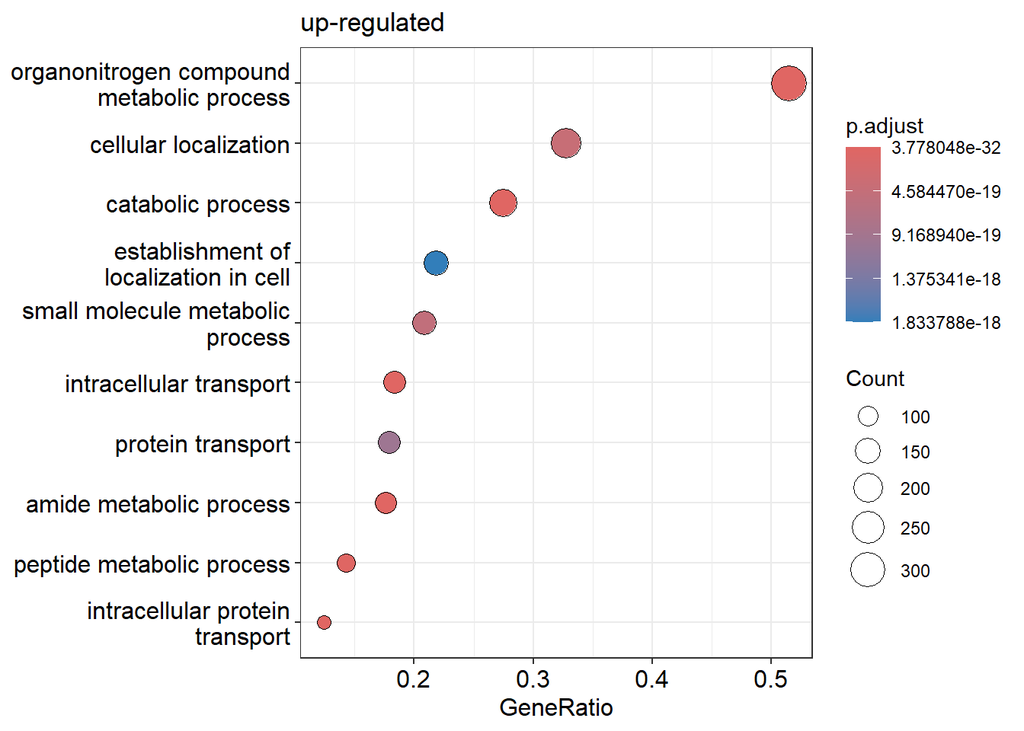

```r
enrichplot::dotplot(gp_mod_enrich_up_BP, showCategory = 10) + ggplot2::labs(title = "up-regulated") + ggplot2::scale_color_gradient(low = "lightseagreen", high = "darkorange1")
```

## Down-regulated proteins

```r
# enrichment analysis using gene names
multi_gp_down_reg <- gost(list("down-regulated" = down_names$name), multi_query = FALSE, evcodes =TRUE)
# modify the g:Profiler data frame
gp_mod_down = multi_gp_down_reg$result[, c("query", "source", "term_id","term_name", "p_value", "query_size", "intersection_size", "term_size", "effective_domain_size", "intersection")]
gp_mod_down <- gp_mod_down[order(gp_mod_down$p_value), ]
# BP
gp_mod_down_BP <- gp_mod_down[gp_mod_down$source == "GO:BP", ]
gp_mod_down_BP$GeneRatio <- paste0(gp_mod_down_BP$intersection_size,  "/", gp_mod_down_BP$query_size)
gp_mod_down_BP$BgRatio <-  paste0(gp_mod_down_BP$term_size, "/", gp_mod_down_BP$effective_domain_size)
names(gp_mod_down_BP) <- c("Cluster", "Category", "ID", "Description", "p.adjust", "query_size", "Count", "term_size", "effective_domain_size", "geneID", "GeneRatio", "BgRatio")
gp_mod_down_BP$geneID <- gsub(",", "/", gp_mod_down_BP$geneID)
gp_mod_enrich_down_BP <- new("enrichResult", result = gp_mod_down_BP)
```

Draw enrichment plot:

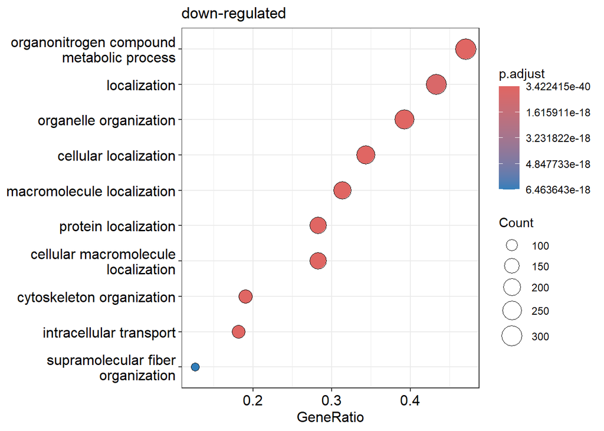

```r
enrichplot::dotplot(gp_mod_enrich_down_BP, showCategory = 10) + ggplot2::labs(title = "down-regulated") + ggplot2::scale_color_gradient(low = "lightseagreen", high = "darkorange1")
```

Biological explanation: We can see the interesting result that some gene groups is up and down regulated simultaneously (For instance, organonitrogen compound metabolic process, intracellular transport). We can notice that these two lists includes very simmilar group(for example, localisation and cellular localisation). It can be explained that The Calcific Aortic Valve Disease is characterised thickening and calcification of the aortic valve leaflets. For this process cells must be rebuilt and that is why we see that some of transport, regulation and even organisation genes are down regulated but another ones are up regulated.